# Reading-Writing-Files

Text files with the .txt extension or Python script files with the .py extension are examples of plaintext files. Your programs can easily read the contents of plaintext files and treat them as an ordinary string value.

Binary files are all other file types, such as word processing documents, PDFs, images, spreadsheets, etc.

To open a file we use `open()` and pass the file you want to open. We can open a file to read or write.

```python
#Let's first set the directory
import os
os.chdir("/Users/ariedamuco/Dropbox (CEU Econ)/TextAnalysisCEU/Input")
```

```python
helloFile = open("Hello.txt")
```

```python
helloFile
```

```
<_io.TextIOWrapper name='Hello.txt' mode='r' encoding='UTF-8'>
```

```python
helloContent = helloFile.read()
```

```python
helloContent
```

```
'I don\'t know why you say, "Goodbye", I say, "Hello"'
```

```python
budapest = open("budapest.txt", mode='r', encoding="utf-8" )
```

```python
budapest.readlines()
```

```
['The history of Budapest began when an early Celtic settlement transformed into the Roman town of Aquincum, the capital of Lower Pannonia.\n',
 'The Hungarians arrived in the territory in the late 9th century.\n',
 ' The area was pillaged by the Mongols in 1241.\n',
 ' Buda, the settlements on the west bank of the river, became one of the centres of Renaissance humanist culture by the 15th century.']
```

```python
type(budapest.readlines())
```

```
list
```

We can also write our own text files.

```python
MyFile=open("../Output/first_file.txt",'w')
```

```python
MyFile.write("This is the first file that I write with Python.")
```

```
48
```

```python
MyFile.close()
```

```python
MyFile=open("../Output/first_file.txt",'w')
```

```python
Lines=["First Line","Second Line","Third Line","Fourth Line"]
```

```python
for line in Lines:
    MyFile.write(line+ "\n")
```

```python
MyFile.close()
```

```python
for line in Lines:
    print(line+ "\n")
```

```
First Line

Second Line

Third Line

Fourth Line
```

In case you want to append the list to the first line you wrote previously, use append mode.

```python
!pip install Wikipedia
```

```
You are using pip version 10.0.1, however version 19.2.3 is available.
```

```python
import wikipedia
```

```python
wikipedia.search("Budapest")
```

```
['Budapest',
 'The Grand Budapest Hotel',
 'Hungarian Revolution of 1956',
 'Budapest Ferenc Liszt International Airport',
 'Budapest Bank',
 'Budapest Memorandum on Security Assurances',
 'Hungarian Parliament Building',
 'Siege of Budapest',
 'Budapest Highflyer',
 'List of films shot in Budapest']
```

```python
BP = wikipedia.page('Budapest')
```

```python
BP.title
```

```
'Budapest'
```

```python
BP.url
```

```
'https://en.wikipedia.org/wiki/Budapest'
```

```python
Budapest=wikipedia.summary("Budapest")
```

```python
Budapest
```

```
"Budapest (, Hungarian pronunciation: [ˈbudɒpɛʃt]) is the capital and the most populous city of Hungary, and the tenth-largest city in the European Union by population within city limits. The city has an estimated population of 1,752,286 over a land area of about 525 square kilometres (203 square mi…
```

```python
BP_page = BP.content
```

```python
BP_page
```

```
'Budapest (, Hungarian pronunciation: [ˈbudɒpɛʃt]) is the capital and the most populous city of Hungary, and the tenth-largest city in the European Union by population within city limits. The city has an estimated population of 1,752,286 over a land area of about 525 square kilometres (203 square mi…
```

### Challenge: Write the string stored with the name BP_page in a file named `Budapest_wiki.txt`. Save the file in the `Output` folder.

```python
import re
clean_BP=re.sub('[^a-zA-Z]+', ' ', BP_page)
```

```python
tokenized_BP=clean_BP.lower().split()
```

```python
tokenized_BP[0:10]
```

```
['budapest',
 'hungarian',
 'pronunciation',
 'bud',
 'p',
 't',
 'is',
 'the',
 'capital',
 'and']
```

### Challenge: Open the file nltk_stopwords.txt and store it's content in a list called `nltk_stopwords` where each element of the list is a line of the document. Use the method `replace()` if needed.

```python
nltk= open("nltk_stopwords.txt", mode='r')
nltk_stopwords=[element.replace("\n","") for element in nltk.readlines()]
```

```python
BP_stopwords_removed = [word for word in tokenized_BP if word not in nltk_stopwords and len(word)>3]
```

```python
from collections import Counter

dict_BP=Counter(BP_stopwords_removed)
dict_BP
```

```
Counter({'budapest': 263,
         'hungarian': 89,
         'pronunciation': 2,
         'capital': 24,
         'populous': 3,
         'city': 152,
         'hungary': 77,
         'tenth': 1,
         'largest': 27,
         'european': 31,
         'union': 3,
         'population': 21,
         'within': 14,
         'limits': 4,
         'estimated': 2,
         'land': 2,
         'area': 20,
         'square': 45,
         'kilometres': 17,
         'miles': 7,
         'county': 4,
         'forms': 1,
         'centre': 23,
         'metropolitan': 7,
         'comprising': 1,
         'history': 9,
         'began': 2,
         'early': 9,
         'celtic': 1,
         'settlement': 4,
         'transformed': 1,
         'roman': 10,
         'town': 2,
         'aquincum': 9,
         'lower': 2,
         'pannonia': 3,
         'hungarians': 8,
         'arrived': 1,
         'territory': 6,
         'late': 8,
```

[output cut: 946 more lines]

```
         'spires': 1,
         'sloping': 1,
         'bustling': 1,
         'oriental': 1,
         'bazaar': 1,
         'filled': 1,
         'chatter': 1,
         'camel': 1,
         'caravans': 1,
         'yemen': 1,
         'india': 1,
         'fact': 1,
         'functioning': 1,
         'bathhouses': 1,
         ...})
```

```python
import matplotlib.pyplot as plt
from wordcloud import WordCloud
```

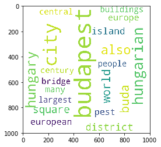

```python
wc = WordCloud(background_color="white",width=1000,height=1000,
               max_words=20,relative_scaling=0.5,
               normalize_plurals=False).generate_from_frequencies(dict_BP)
plt.imshow(wc)
```

```python
#write the dictionary in a text file
Write_BP=open('../Output/Budapest_counter_freq.txt', 'w')
Write_BP.write('word' +";" +"frequency"+"\n")
for key, value in Counter(dict_BP).items():
    print (key, value)
    Write_BP.write(key + ';' + str(value) + "\n")
Write_BP.close()
```

```
budapest 263
hungarian 89
pronunciation 2
capital 24
populous 3
city 152
hungary 77
tenth 1
largest 27
european 31
union 3
population 21
within 14
limits 4
estimated 2
land 2
area 20
square 45
kilometres 17
miles 7
county 4
forms 1
centre 23
metropolitan 7
comprising 1
history 9
began 2
early 9
celtic 1
settlement 4
transformed 1
roman 10
town 2
aquincum 9
lower 2
pannonia 3
hungarians 8
arrived 1
territory 6
late 8
```

[output cut: 2641 more lines]

```
concise 2
cambridge 2
histories 1
fallon 1
steve 1
boston 1
massachusetts 1
https 1
lonelyplanet 1
links 1
website 2
tourist 1
visitbudapest 1
portal 1
jewishgen 1
```

```python
"""
# Using the csv library
import csv

with open('Output/Budapest_counter.csv', 'w') as csv_file:
    writer = csv.writer(csv_file, delimiter=';')
    writer.writerow(['word','frequency'])
    for key, value in dict_counts.items():
       writer.writerow([key, value])
"""
```

```
"\n# Using the csv library\nimport csv\n\nwith open('Output/Budapest_counter.csv', 'w') as csv_file:\n    writer = csv.writer(csv_file, delimiter=';')\n    writer.writerow(['word','frequency'])\n    for key, value in dict_counts.items():\n       writer.writerow([key, value])\n"
```

With Python we can open, read and write other types of files. One of them is `pdf` format. While we can read pdfs we cannot write pdf from scratch, we only write content that is already in pdf format. To do this, we'll use another third party module called PyPDF2.

```python
#install third party module
! pip install PyPDF2
```

```
You are using pip version 10.0.1, however version 19.2.3 is available.
```

```python
import PyPDF2
```

```python
AEJ_health=open('pdfs/app20170295.pdf', "rb") #read binary
reader_health=PyPDF2.PdfFileReader(AEJ_health)
```

```python
reader_health
```

```
<PyPDF2.pdf.PdfFileReader at 0x7fb318028b70>
```

```python
reader_health.numPages
```

```
31
```

```python
page1_health=reader_health.getPage(0)
```

```python
page1_health.extractText()
```

```
'American Economic Journal: Applied Economics 2019, 11(2): 302Œ332\n https://doi.org/10.1257/app.20170295\n302* Curto: Department of Health Policy and Management, T.H. Chan School of Public Health, Harvard University, \n677 Huntington Avenue, Boston, MA 02115-6028 \n(email: vcurto@hsph.harvard.edu);…
```

```python
writer_AEJ_health=PyPDF2.PdfFileWriter()
```

```python
writer_AEJ_health.addPage(page1_health)
```

```python
outputFile_health=open('../Output/AEJ_health_abstract.pdf','wb')
writer_AEJ_health.write(outputFile_health)
outputFile_health.close()
```

```python
#read other AEJ file
AEJ_temperature=open('pdfs/app20170223.pdf', "rb")
reader_temperature=PyPDF2.PdfFileReader(AEJ_temperature)
page1_temperature=reader_temperature.getPage(0)
```

```python
writer_AEJ=PyPDF2.PdfFileWriter()
writer_AEJ.addPage(page1_temperature)
writer_AEJ.addPage(page1_health)
outputFile=open('../Output/AEJ_combined.pdf','wb')
writer_AEJ.write(outputFile)
outputFile.close()
```

### Challenge: Write a function that combines odd pages from `app20170295.pdf` and `app20170223.pdf`.

### References

https://pypi.org/project/wikipedia/

https://medium.com/@Alexander_H/scraping-wikipedia-with-python-8000fc9c9e6c

https://automatetheboringstuff.com/chapter8/

https://automatetheboringstuff.com/chapter13/